# Using R for Better Workflows

Mark Kane & Fraser Hay  
Conestoga College

October 27, 2020

# A note to users:

This presentation is best viewed in **full-screen mode**!

For most browsers - simply hit **F11** to toggle it (on and off).

If you wish to view the code for this presentation, we are hosting it over at the [CIRPA CodeShare](https://github.com/cirpa-acpri/codeshare) site (R section).

# Outline

- Importance of efficient and effective workflows
- Traditional vs modern data analysis workflow
- Conestoga’s old & new workflows for survey reporting
- Overview of R Markdown
- How we are using R Markdown to improve our workflows
- Finished product
- Advantages & disadvantages of using R markdown for survey reporting

# Efficient and Effective Workflows

### Why should we care?

- Reproducible – Others can redo the analysis and get the same results
- Reusable – Do not have to start from scratch for each project
- Reduce Errors – Less manual steps lead to less errors
- Easier to update / fix errors – Can make a change in an initial step and the change will flow through seamlessly

# Why is Reproducibility Difficult?

- Poor or non-existent documentation
- A small number of reasonable decisions can lead to a large number of end results
  - How do I handle missing values?
  - How do I code the variables?
  - Do I collapse sparse categories?
  - Should the results be weighted?

If we assume we have 10 binary decisions in the analysis this would lead to 2<sup>10</sup> = 1024 different paths

# Data Analysis Workflow

- Import Data
- Data Manipulation
- Data Analysis & Visualization
- Reporting

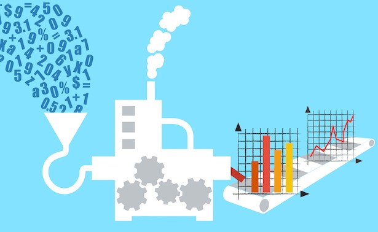

# Traditional vs Modern Workflows

### Traditional

- Menu Driven
- Copy-and-paste
- Error prone
- Not easily reproducible

WET approach – **W**e **E**njoy **T**yping

### Modern

- All steps performed using code
- Repeated steps are automated and standardized
- Reduces chances for errors
- Understandable & usable by others

DRY approach – **D**on’t **R**epeat **Y**ourself

# Conestoga’s Old Workflow

- Uses 4 software platforms
- Includes manual processes that are not reproducible

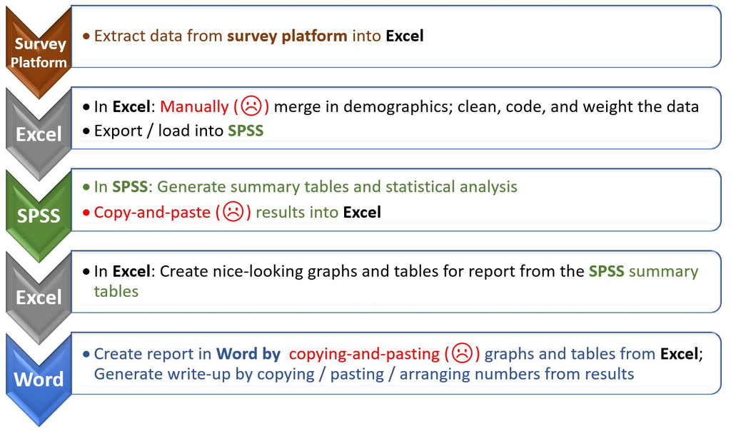

# Conestoga’s New Workflow

- Uses 2 software platforms

[figure not shown]

# What is R Markdown?

- A (free) package in R that allows you to create reproducible workflows.

[video not shown]

# How are we using R & R Markdown?

How are WE using R & R Markdown?

[figure not shown]

# How are we using R & R Markdown? (1/8)

### Making functions to save time

- Frequency tables
- Data transformations, dummy variables
- Lots of loops
- Graphs, plots and formatting

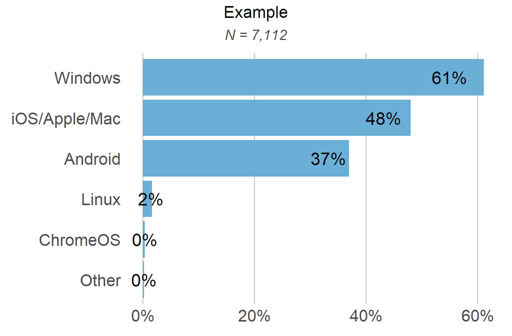

```r
frq_g_simple(data, "Example")
```

- Sharing them on GitHub (https://github.com/cirpa-acpri/codeshare)

# How are we using R & R Markdown? (2/8)

### Making the report before the data is in – Dynamic code / statements

```r
observation = round(mean(variable),0)
```

```
## [1] "<i>Example:</i> `r observation`% of students indicated they prefer driving in the city."
```

- *Example:* 23% of students indicated they prefer driving in the city.

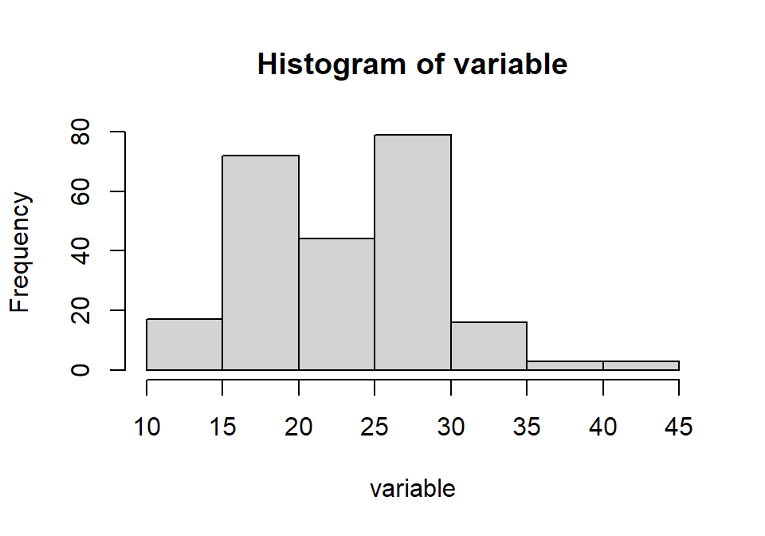

```r
hist(variable)
```

# How are we using R & R Markdown? (3/8)

### Plots for any occasion

- Condensing common graphs (half-screen of code) into parameterized one-line function-calls

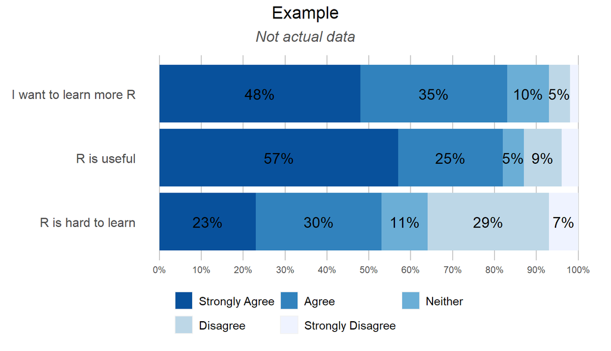

```r
frq_g_battery(data, "Example", subtitle = "Not actual data")
```

- Many other types possible (https://www.r-graph-gallery.com/index.html)

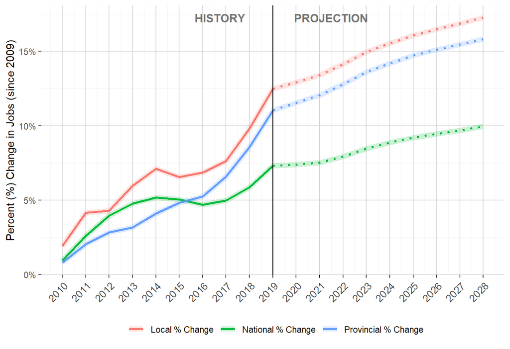

# How are we using R & R Markdown? (4/8)

### Tabs & buttons (HTML reports only)

- Creates interactivity and organization in reports.

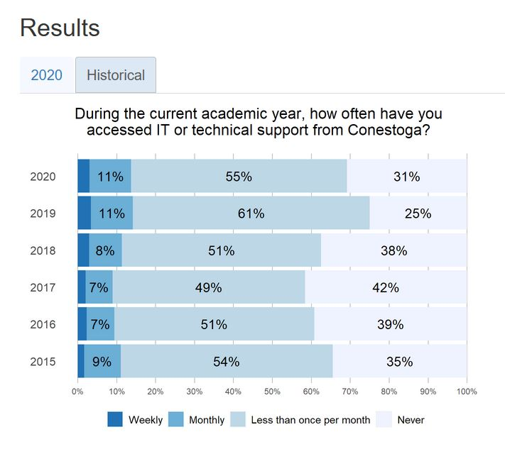

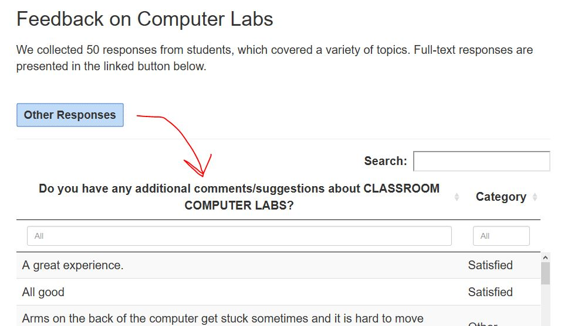

# How are we using R & R Markdown? (5/8)

### (Lots of) Cross-tabulation tables

- Our most common reporting operation after frequencies. Looping through variables, showing breakdowns.

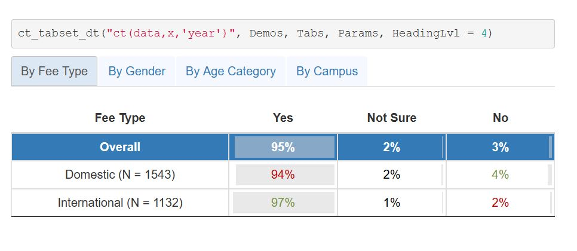

# How are we using R & R Markdown? (6/8)

### Images / videos / links

[figure not shown]

[video not shown]

https://github.com/cirpa-acpri/codeshare

# How are we using R & R Markdown? (7/8)

### PDF / file embedding

[figure not shown]

# How are we using R & R Markdown? (8/8)

### Tweaking appearances

- Most of our reports are in HTML - most flexibility in aesthetics
- Can use HTML, JavaScript, and CSS to improve functionality and appearance
  - Colours, sizes, effects, show/hide, triggers, formatting, elements, etc.
- Can re-use that code, or employ as templates for other projects

# Finished Product

- Get scrolling!
- Fig 1: A title, logo, and outset.

[figure not shown]

- Fig 2: Basic graphs.

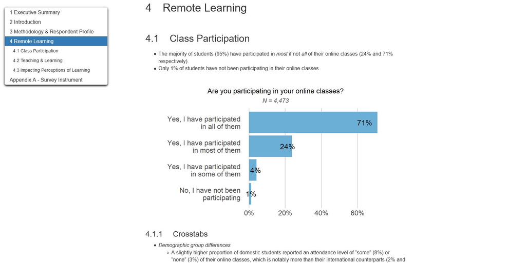

- Fig 3: Importing a picture - of an Excel table.
  - For those times you have non-R collaborators.

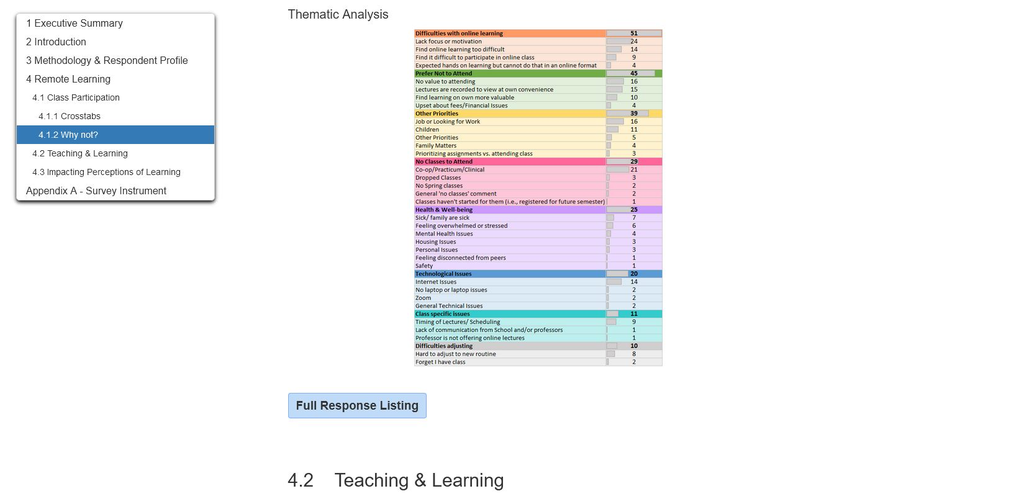

- Fig 4: Stacked bar charts

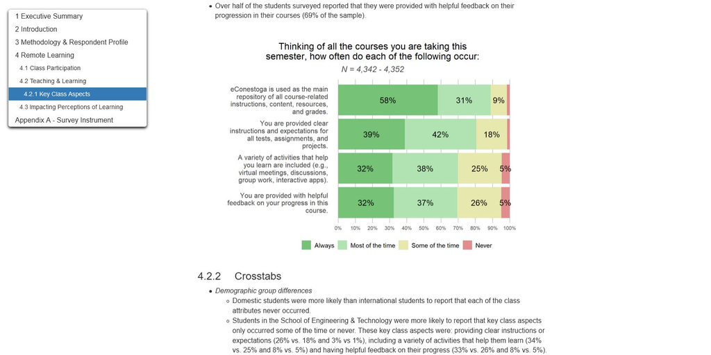

- Fig 5: Oh look, a decision tree!

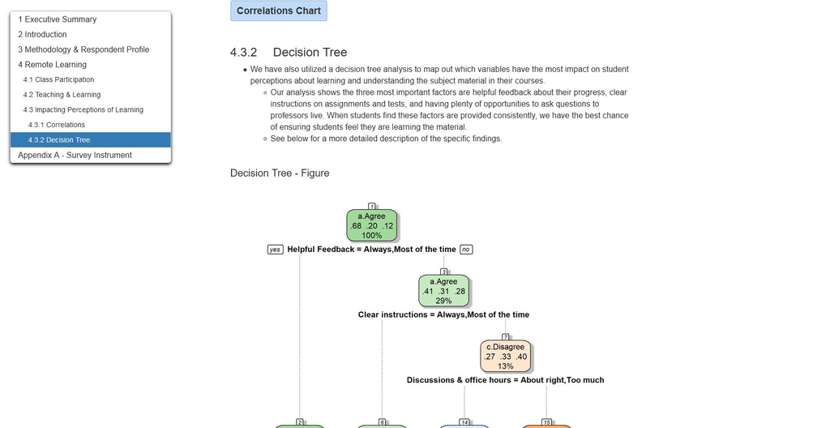

- End of figures.

# Effect on our Workflow

- After an initial time investment, we now are reaping significant benefits in terms of reproducibility and time savings
  - Reports that would previously take around a *month* now only take a about a *week*
- Cascading data and report adjustments implemented in minutes
- We’re starting to move some of our routine / mainline reports (eg. Labour Market, Program Review Reporting) into an R format
  - Also using for ad-hoc requests when R is the best tool for the job
- We’re learning and borrowing (stealing) code and ideas from each other
  - R makes big projects, like dabbling in machine learning, within arms reach

# Advantages of Using R Markdown for Survey Reporting

- Reproducible → reusable (in whole or in part)
- Can easily rerun code if an error is made or a change is requested
  - Example: new cases, new weighting, adding new cross-tab breakdowns
- All steps taken, from data cleaning to reporting, recorded in one software package
  - Fewer working files, fewer platforms, no copy/paste errors
- Reports and elements can be parameterized
- Multiple output formats: HTML / websites, PDF, Word, PowerPoint
- Can use multiple languages: SQL, Python, HTML, CSS
- Large community of R users
- Free ($0), open source software

# Disadvantages of Using R Markdown for Survey Reporting

- Learning curve
  - *Solution: Google and ask the massive online community*
- If there is an error in one of the code chunks the report will not compile
  - *Solution: Use Google, a support group ([CIRPA Forums](https://cirpa.member365.com/sharingnetwork/dashboard) / [CodeShare](https://github.com/cirpa-acpri/codeshare)), and be patient while troubleshooting*
- If report is HTML, no ability to track changes or add comments
  - New report formats may require an adjustment for stakeholders
  - *Solution: Export to Word for collaborative revisions*
- Software package version control
  - Different team members may be using different versions of the same R libraries
  - *Solution: Use tools / packages to track your project versionning*
- Every change to the report requires re-running (compiling) the entire report
  - *Solution: Break code into smaller chunks and only render what you’re working on*

# Resources

[CIRPA’s CodeShare GitHub Site](https://github.com/cirpa-acpri/codeshare)  
https://github.com/cirpa-acpri/codeshare

[R Studio: Introduction to R Markdown](https://rmarkdown.rstudio.com/lesson-1.html)  
https://rmarkdown.rstudio.com/lesson-1.html

[Getting Started with R Markdown (RStudio Webinar)](https://rstudio.com/resources/webinars/getting-started-with-r-markdown/)  
https://rstudio.com/resources/webinars/getting-started-with-r-markdown/

[R Studio: Education for Beginners (in R)](https://education.rstudio.com/learn/beginner/)  
https://education.rstudio.com/learn/beginner/

[“R for Data Science”; eBook (made in Bookdown), by Garrett Grolemund & Hadley Wickham](https://r4ds.had.co.nz/index.html)  
https://r4ds.had.co.nz/index.html

[“R Markdown: The Definitive Guide”; eBook (made in Bookdown), by Yihui Xie, J. J. Allaire, Garrett Grolemund](https://bookdown.org/yihui/rmarkdown/)  
https://bookdown.org/yihui/rmarkdown/

[“R Markdown Cookbook”; eBook (made in Bookdown), by Yihui Xie, Christophe Dervieux, Emily Riederer](https://bookdown.org/yihui/rmarkdown-cookbook/)  
https://bookdown.org/yihui/rmarkdown-cookbook/

# Scary Movie… with a Happy Ending

[video not shown]

# End

[figure not shown]

Thank you!

Mark Kane

Statistician

Fraser Hay

Institutional Research Analyst